# Nieklasyczne metody statystyki

Nieparametryczna estymacja dystrybuanty

Julia Deptulska

# 1 Wprowadzenie

Cel: wyznaczenie obszaru ufności dla dystrybuanty nieznanego rozkładu, a nie tylko oszacowania parametrów, od jakich zależą jej wartości.

- Brzegi tego obszaru są wykresami funkcji „przedziałami stałych” (funkcji schodkowych).
- Jeżeli przy wyznaczaniu pasma ufności dla dystrybuanty otrzymamy lewy kraniec przedziału będący liczbą ujemną, to zastępujemy ją przez zero.
- Jeżeli otrzymamy prawy kraniec przedziału większy od jedności, to przyjmujemy, że jest on równy jeden.
- Określenie obszaru ufności dla dystrybuanty w przedstawiony sposób polega na wyznaczeniu przedziałowego oszacowania dla każdej wartości dystrybuanty.

## 1.1 Funkcja CDF

Funkcja w programie R odpowiedzialna za estymację to np. CDF z pakietu spatstat. CDF jest metodą ogólną, z metodą dla klasy “gęstość”.

Oblicza ona skumulowaną funkcję rozkładu, której gęstość prawdopodobieństwa została oszacowana i zapisana w obiekcie f. Obiekt f musi należeć do klasy “gęstość” i zazwyczaj zostałby uzyskany z wywołania funkcji gęstość.

## 1.2 Funkcja kde

Pakiet R o nazwie snpar zawiera kilka uzupełniających metod statystyki nieparametrycznej, w tym test kwantylowy, test trendu Coxa-Stuarta, test przebiegów, test normalnego wyniku, estymację jądra PDF i CDF, estymację regresji jądra i test jądra Kołmogorowa-Smirnowa.

Funkcja kde zawiera obliczanie zarówno nieparametrycznego estymatora jądra funkcji gęstości prawdopodobieństwa (PDF) jak i funkcji rozkładu skumulowanego (CDF).

## 1.3 Przykład 1.

```r
   b <- density(runif(10))
   f <- CDF(b)
   f(0.5)
```

```
## [1] 0.4722615
```

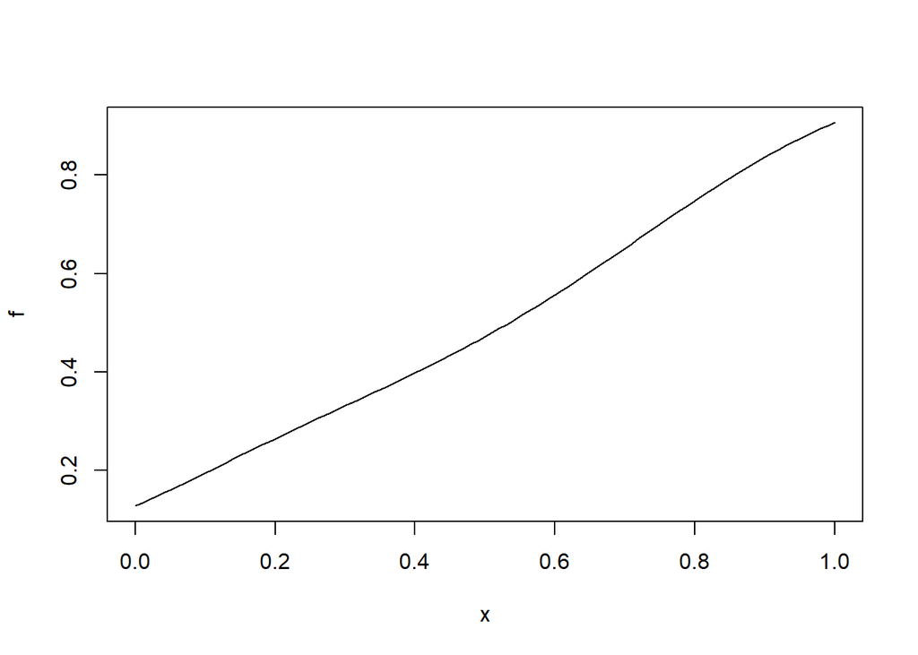

```r
   plot(f)
```

## 1.4 Przykład 2.

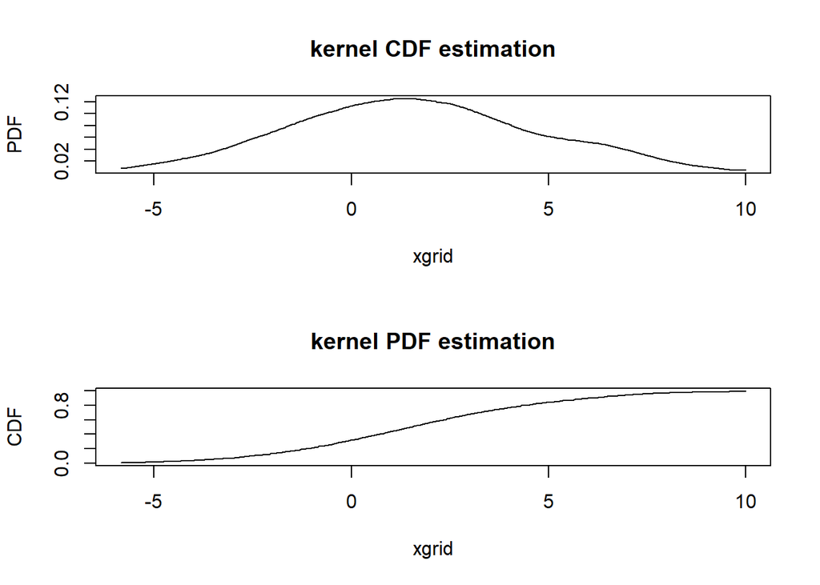

[output not shown]

[output cut: 131 more lines]

```r
x <- rnorm(200,2,3)
# with default bandwidth
kde(x, kernel = "quar", plot = TRUE)
```

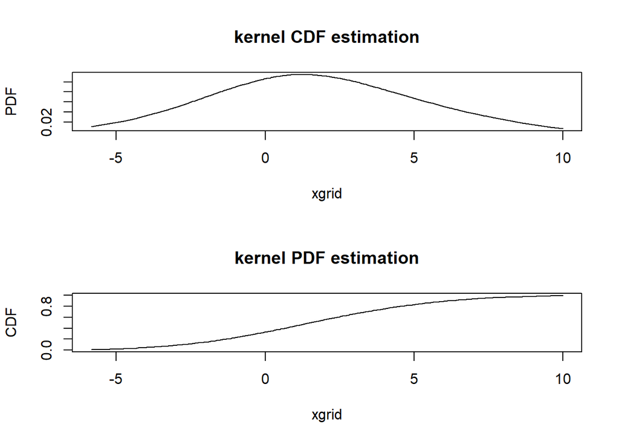

[output not shown]

[output cut: 131 more lines]

```r
# with specified bandwidth
kde(x, h = 4, kernel = "quar", plot = TRUE)
```

## 1.5 Przeczytaj

Przeczytaj artykuł naukowy [“Kernel-smoothed cumulative distribution function estimation with akdensity”](https://journals.sagepub.com/doi/pdf/10.1177/1536867X1201200313) autorstwa Philippe Van Kerm.

## 1.6 Zadanie

Posłużymy się zbiorem danych diagnozy społecznej.

Na jego podstawie Twoim zadaniem jest oszacowanie rozkładu “p64 Pana/Pani wlasny (osobisty) dochod miesieczny netto (na reke)” według województw/płci.

Postaraj się oszacować zarówno rozkład gęstości jak i skumulowanej gęstości (dystrybuanty).

```r
data("diagnoza")
data("diagnozaDict")
```

```r
dane <- diagnoza %>%
  select(wojewodztwo, plec, gp64) %>%
  filter(!is.na(gp64), gp64 > 0)
```

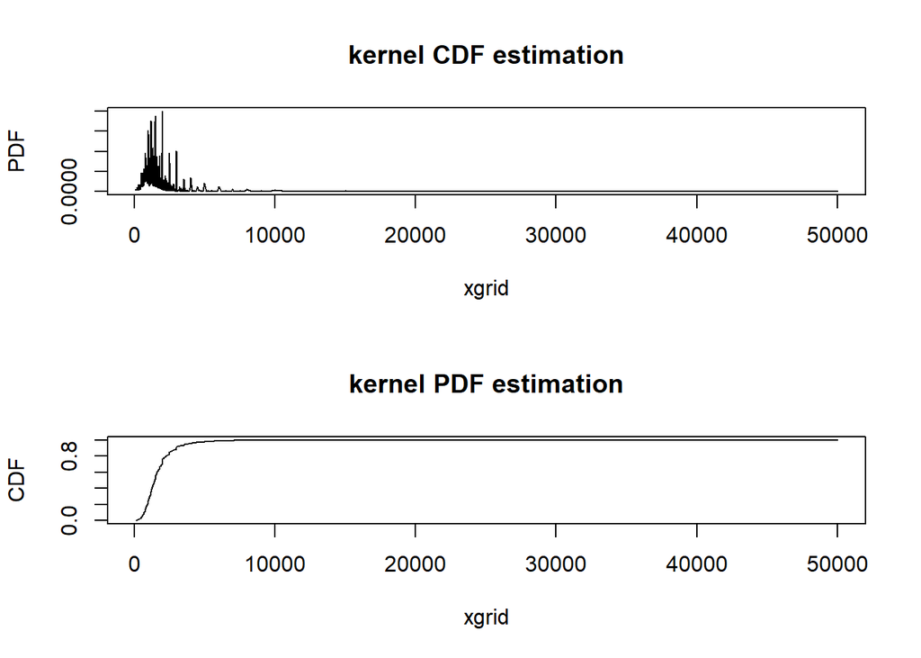

[output not shown]

[output cut: 11153 more lines]

```r
kde(dane$gp64, kernel = "quar", plot = TRUE)
```

## 1.7 Zadanie 1.1

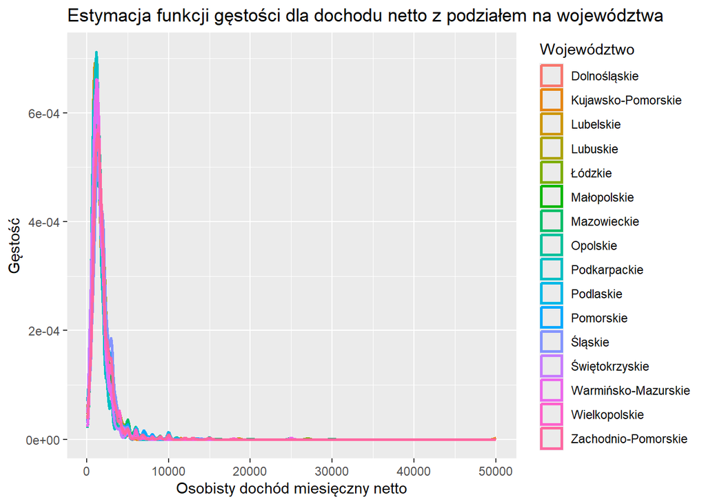

```r
ggplot(dane, aes(x = gp64, color = wojewodztwo)) +
  geom_density(size = 1) +
  labs(title = "Estymacja funkcji gęstości dla dochodu netto z podziałem na województwa",
       x = "Osobisty dochód miesięczny netto",
       y = "Gęstość",
       color = "Województwo")
```

Przybliżony wykres:

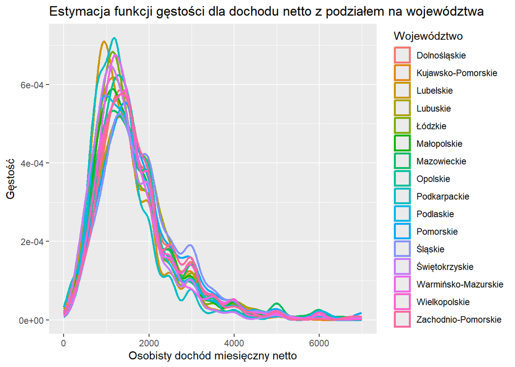

```r
ggplot(dane, aes(x = gp64, color = wojewodztwo)) +
  geom_density(size = 1) +
  scale_x_continuous(limits = c(0, 7000)) +
  labs(title = "Estymacja funkcji gęstości dla dochodu netto z podziałem na województwa",
       x = "Osobisty dochód miesięczny netto",
       y = "Gęstość",
       color = "Województwo")
```

## Zadanie 1.2

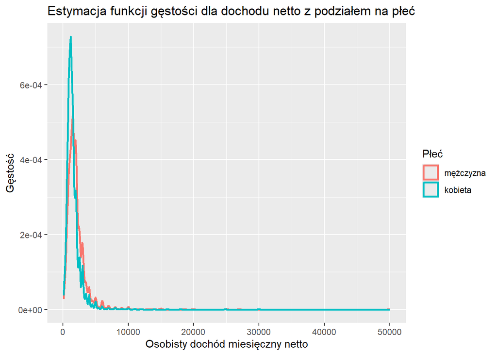

```r
ggplot(dane, aes(x = gp64, color = plec)) +
  geom_density(size = 1) +
  labs(title = "Estymacja funkcji gęstości dla dochodu netto z podziałem na płeć",
       x = "Osobisty dochód miesięczny netto",
       y = "Gęstość",
       color = "Płeć")
```

Przybliżony wykres

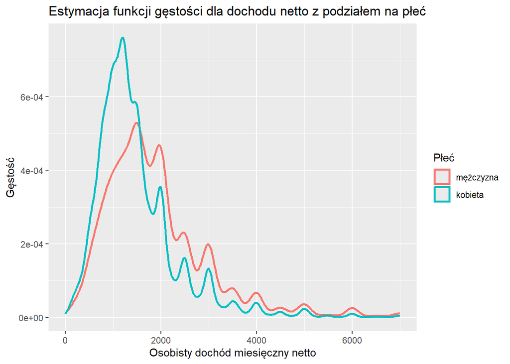

```r
ggplot(dane, aes(x = gp64, color = plec)) +
  geom_density(size = 1) +
  scale_x_continuous(limits = c(0, 7000)) +
  labs(title = "Estymacja funkcji gęstości dla dochodu netto z podziałem na płeć",
       x = "Osobisty dochód miesięczny netto",
       y = "Gęstość",
       color = "Płeć")
```